# Author: Anna Golovchenko

## Motivation

A small business may significantly benefit by applying simple machine learning techniques to solve daily troubles causing feasible costs. While the range of everyday troubles is wide, the problem of no-shows e.g. situations when a client does not come for an appointment is common for restaurants, hair and beauty salons, private dentist cabinets etc. Of course, each case would be unique so there shouldn't be a unique algorithm predicting no-shows for different types of small business at the same time. In this study, we aim to solve the no-show prediction problem for hair salon proposed on [kaggle.com](https://www.kaggle.com/frederickferguson/hair-salon-no-show-data-set). A no-show prediction service would allow hair salons to select from a variety of treatment options at the time of the booking such as requiring a non-refundable deposit or scheduling the appointment at a different time, location or with a different service provider such that the potential no-show would have less business and customer experience impact.

## Data

### Features:

`noshow` -- Did the client no-show or execute an out-of-policy cancellation for this booking? (0 - no, 1 - yes) (dependent)

`book_tod` -- The booking time of day.

`book_dow` -- The booking day-of-week.

`book_category` -- The booked service category (COLOR or STYLE)

`book_staff` -- The staff member to provide the service.

`last_category` -- The client's last booked service category before the current booking or today whichever is greater.

`last_staff` -- The staff member who provided the client's last service before the current booking or today whichever is greater.

`last_day_services` --The number of services provided to the client on their last visit before the current booking or today whichever is greater.

`last_receipt_tot` -- The amount paid by the client on their last visit before the current booking or today whichever is greater.

`last_dow` -- The day-of-week of the client's last booking before before the current booking or today whichever is greater.

`last_tod` -- The time-of-day of the client's last booking before the current booking or today whichever is greater.

`last_noshow` -- Did the client no-show on their last booking before the current booking or today whichever is greater? (0 - no, 1 - yes)

`last_prod_flag` -- Did the client buy a retail product on their last booking before the current booking or today whichever is greater? (0 - no, 1 - yes)

`last_cumrev` -- The client's cumulative service revenue as of their last booking before the current booking or today whichever is greater.

`last_cumbook` -- The client's cumulative number of bookings as of their last booking before the current booking or today whichever is greater.

`last_cumstyle` -- The client's cumulative number of STYLE bookings as of their last booking before the current booking or today whichever is greater.

`last_cumcolor` -- The client's cumulative number of COLOR bookings as of their last booking before the current booking or today whichever is greater.

`last_cumprod` -- The client's cumulative number of bookings with retail product purchases as of their last booking before the current booking or today whichever is greater.

`last_cumcancel` --The client's cumulative number of appointment cancellations as of their last booking before the current booking or today whichever is greater.

`last_cumnoshow` -- The client's cumulative number of no-shows as of their last booking before the current booking or today whichever is greater.

`recency` -- The number of days since the client's last booking before the current booking or today whichever is greater.

## Project aims

Apart from just predicting the no-shows with the highest score possible we will also concentrate on the explanation of the mechanisms causing a no-show. Therefore the aims are:

- Investigate the data
- Build a prediction model
- Identify the features that contribute the most
- Explain the mechanisms underlying the model

## Data exploration

```python
import warnings
warnings.filterwarnings('ignore')

import numpy as np
import matplotlib.pyplot as plt
import pandas as pd
import seaborn as sns
% matplotlib inline

noshow = pd.read_csv("hair_salon_no_show_wrangled_df.csv")
noshow = noshow.drop(['Unnamed: 0'], axis = 1)
noshow.head()
```

|  | book_tod | book_dow | book_category | book_staff | last_category | last_staff | last_day_services | last_receipt_tot | last_dow | last_tod | ... | last_prod_flag | last_cumrev | last_cumbook | last_cumstyle | last_cumcolor | last_cumprod | last_cumcancel | last_cumnoshow | noshow | recency |
| --- | --- | --- | --- | --- | --- | --- | --- | --- | --- | --- | --- | --- | --- | --- | --- | --- | --- | --- | --- | --- | --- |
| 0 | afternoon | Wednesday | STYLE | JJ | NaN | NaN | 0 | 0.0 | NaN | NaN | ... | 0 | 0 | 0 | 0 | 0 | 0 | 0 | 0 | 0 | 0 |
| 1 | morning | Wednesday | COLOR | JOANNE | NaN | NaN | 0 | 0.0 | NaN | NaN | ... | 0 | 0 | 0 | 0 | 0 | 0 | 0 | 0 | 0 | 0 |
| 2 | NaN | Wednesday | STYLE | JJ | COLOR | JOANNE | 2 | 262.0 | Wednesday | morning | ... | 1 | 262 | 2 | 1 | 1 | 2 | 0 | 0 | 0 | 35 |
| 3 | afternoon | Thursday | STYLE | KELLY | NaN | NaN | 0 | 0.0 | NaN | NaN | ... | 0 | 0 | 0 | 0 | 0 | 0 | 0 | 0 | 0 | 0 |
| 4 | evening | Saturday | STYLE | KELLY | STYLE | KELLY | 1 | 35.0 | Thursday | afternoon | ... | 0 | 35 | 1 | 1 | 0 | 0 | 0 | 0 | 0 | 9 |

5 rows × 21 columns

```python
noshow.describe() # describe all the numeric features
```

|  | last_day_services | last_receipt_tot | last_noshow | last_prod_flag | last_cumrev | last_cumbook | last_cumstyle | last_cumcolor | last_cumprod | last_cumcancel | last_cumnoshow | noshow | recency |
| --- | --- | --- | --- | --- | --- | --- | --- | --- | --- | --- | --- | --- | --- |
| count | 1952.000000 | 1952.000000 | 1952.000000 | 1952.000000 | 1952.000000 | 1952.000000 | 1952.000000 | 1952.000000 | 1952.000000 | 1952.000000 | 1952.000000 | 1952.000000 | 1952.000000 |
| mean | 0.545082 | 35.782679 | 0.076332 | 0.114242 | 111.258197 | 1.906762 | 1.520492 | 0.325307 | 0.487193 | 0.280225 | 0.422643 | 0.114754 | 14.402152 |
| std | 0.658514 | 59.371877 | 0.265597 | 0.318186 | 207.927702 | 3.315854 | 2.756585 | 0.827646 | 1.261275 | 0.853646 | 1.319786 | 0.318807 | 21.079495 |
| min | 0.000000 | 0.000000 | 0.000000 | 0.000000 | 0.000000 | 0.000000 | 0.000000 | 0.000000 | 0.000000 | 0.000000 | 0.000000 | 0.000000 | 0.000000 |
| 25% | 0.000000 | 0.000000 | 0.000000 | 0.000000 | 0.000000 | 0.000000 | 0.000000 | 0.000000 | 0.000000 | 0.000000 | 0.000000 | 0.000000 | 0.000000 |
| 50% | 0.000000 | 0.000000 | 0.000000 | 0.000000 | 0.000000 | 1.000000 | 0.000000 | 0.000000 | 0.000000 | 0.000000 | 0.000000 | 0.000000 | 1.000000 |
| 75% | 1.000000 | 60.000000 | 0.000000 | 0.000000 | 132.000000 | 2.000000 | 2.000000 | 0.000000 | 0.000000 | 0.000000 | 0.000000 | 0.000000 | 27.000000 |
| max | 3.000000 | 382.800000 | 1.000000 | 1.000000 | 1276.000000 | 20.000000 | 18.000000 | 7.000000 | 11.000000 | 8.000000 | 9.000000 | 1.000000 | 133.000000 |

### Distribution of the dependent variable

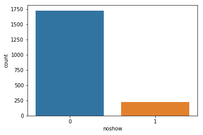

```python
sns.countplot(x='noshow', data=noshow)
```

The data is imbalanced, there are more `0`s than `1`s in the dependent variable.

### Correlation map

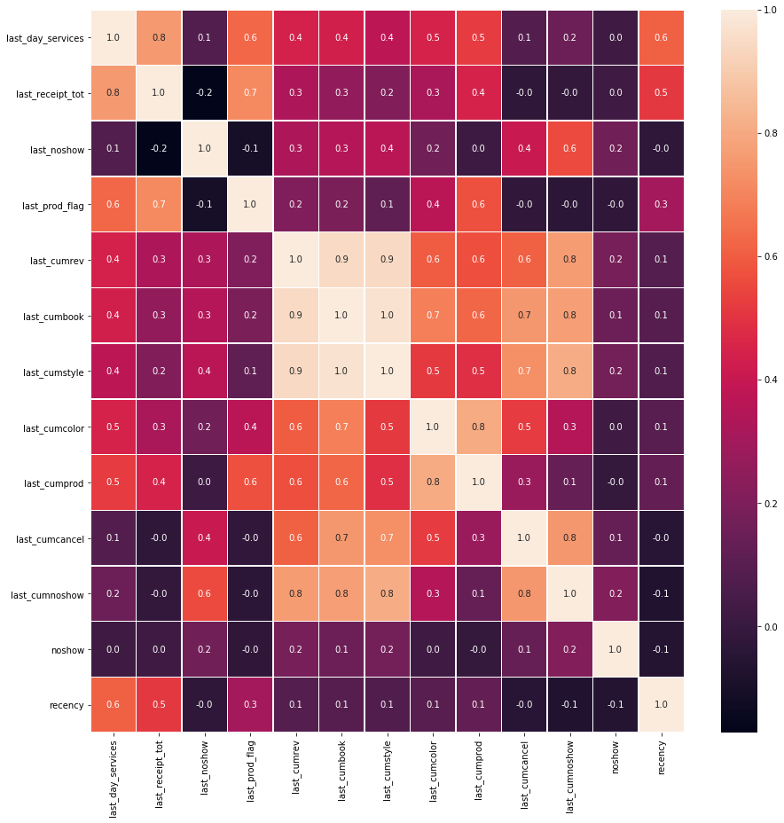

```python
f, ax = plt.subplots(figsize = (15, 15))
sns.heatmap(noshow.corr(), annot = True, linewidths = .5, fmt = '.1f', ax = ax)
plt.show()
```

Highly correlated featrures are:

- `last_receipt_tot` and `last_day_services`
- `last_cumbook`, `last_cumstile`, `last_cumrev` and `last_cumnoshow`

**Who gets more no shows?**

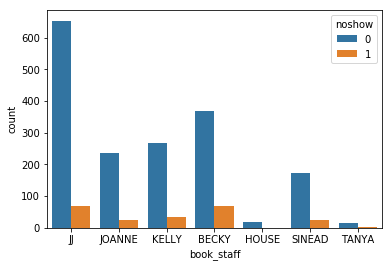

```python
sns.countplot(x='book_staff', hue = "noshow", data=noshow)
```

According to the graph, Becky gets proportionally more no-shows than others.

**Are no shows spread evenly across the day time?**

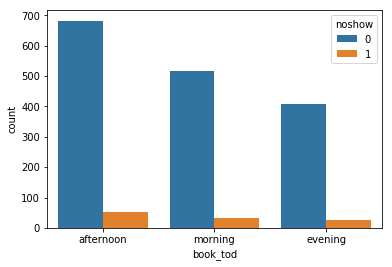

```python
sns.countplot(x = "book_tod", hue = "noshow", data = noshow)
```

It looks like the no-shows are spread evenly.

## Pre-processing

### Missing Values

Are there any values with many missings?

```python
print(noshow.isnull().sum())
```

```
book_tod              235
book_dow                0
book_category           0
book_staff              0
last_category         949
last_staff            949
last_day_services       0
last_receipt_tot        0
last_dow              949
last_tod             1094
last_noshow             0
last_prod_flag          0
last_cumrev             0
last_cumbook            0
last_cumstyle           0
last_cumcolor           0
last_cumprod            0
last_cumcancel          0
last_cumnoshow          0
noshow                  0
recency                 0
dtype: int64
```

Some of the variables contain more than 900 missing values which is a sustainable number considering we have 1952 observations. I suggest to exclude them. There is also a categorical variable (daytime of the booking) that contains 235 missings, here I suggest to substitute missings with `unknown` value.

```python
noshow = noshow.drop(['last_dow','last_tod', 'last_category', 'last_staff'], axis = 1)
noshow = noshow.fillna('unknown')
```

As we have just filled `book_tod` with `unknown` values, let's check how many noshows happen when the day time of the appointment is unknown.

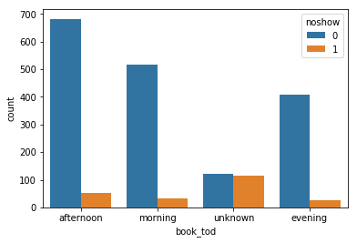

```python
sns.countplot(x = "book_tod", hue = "noshow", data = noshow)
```

Well, almost half of the appointments with unknown time of the day end up with no-shows. Perhaps it would be an informative feature in the model.

The last step we need to take is to convert categorical variables such as `book_tod`, `book_dow` and others into dummies.

```python
# Make dummies for categorigal variables
book_tod = pd.get_dummies(noshow.book_tod)
noshow = noshow.join(book_tod)
book_dow = pd.get_dummies(noshow.book_dow)
noshow = noshow.join(book_dow)
book_category = pd.get_dummies(noshow.book_category)
noshow = noshow.join(book_category)
book_staff = pd.get_dummies(noshow.book_staff)
noshow = noshow.join(book_staff)
noshow.head()
```

|  | book_tod | book_dow | book_category | book_staff | last_day_services | last_receipt_tot | last_noshow | last_prod_flag | last_cumrev | last_cumbook | ... | COLOR | MISC | STYLE | BECKY | HOUSE | JJ | JOANNE | KELLY | SINEAD | TANYA |
| --- | --- | --- | --- | --- | --- | --- | --- | --- | --- | --- | --- | --- | --- | --- | --- | --- | --- | --- | --- | --- | --- |
| 0 | afternoon | Wednesday | STYLE | JJ | 0 | 0.0 | 0 | 0 | 0 | 0 | ... | 0 | 0 | 1 | 0 | 0 | 1 | 0 | 0 | 0 | 0 |
| 1 | morning | Wednesday | COLOR | JOANNE | 0 | 0.0 | 0 | 0 | 0 | 0 | ... | 1 | 0 | 0 | 0 | 0 | 0 | 1 | 0 | 0 | 0 |
| 2 | unknown | Wednesday | STYLE | JJ | 2 | 262.0 | 0 | 1 | 262 | 2 | ... | 0 | 0 | 1 | 0 | 0 | 1 | 0 | 0 | 0 | 0 |
| 3 | afternoon | Thursday | STYLE | KELLY | 0 | 0.0 | 0 | 0 | 0 | 0 | ... | 0 | 0 | 1 | 0 | 0 | 0 | 0 | 1 | 0 | 0 |
| 4 | evening | Saturday | STYLE | KELLY | 1 | 35.0 | 0 | 0 | 35 | 1 | ... | 0 | 0 | 1 | 0 | 0 | 0 | 0 | 1 | 0 | 0 |

5 rows × 38 columns

```python
noshow = noshow.drop(['book_tod', 'book_dow', 'book_category', 'book_staff'], axis = 1)
```

We finished the preprocessing.

## Gradient Boosting Model

Gradient Boosting model is an ensemble of trees built one of the top of another. This model was chosen because it achieves the best accuracy and ROC-AUC scores among others I tried. The only drawback of this model is that the model is hard to interpret.

```python
from sklearn.model_selection import cross_val_score
from sklearn.metrics import accuracy_score, roc_auc_score
from sklearn.model_selection import train_test_split
from sklearn.ensemble import GradientBoostingClassifier

X = noshow.iloc[:, noshow.columns != 'noshow'].values # all the features
y = noshow.iloc[:,11].values # dependent variable
```

### Hyper-parameter optimization via cross-validtion

Let's write the function that will perform data split (default = 1/3), model evaluation with cross-validation if needed and print the Accuracy and ROC-AUC scores along with the feature importance.

```python
from sklearn import cross_validation

def modelfit(alg, X, y, split = 1/3, performCV=True, printFeatureImportance=True, cv_folds=5):

    # Train - test split
    X_train, X_test, y_train, y_test = train_test_split(X, y,
                                                        test_size = split,
                                                        random_state = 666) # 2/3 - train, 1/3 - test

    #Fit the algorithm on the data
    alg.fit(X_train, y_train)

    #Predict training set:
    dtrain_predictions = alg.predict(X_train)
    dtrain_predprob = alg.predict_proba(X_train)

    #Predict test set:
    dtest_predictions = alg.predict(X_test)
    dtest_predprob = alg.predict_proba(X_test)

    #Perform cross-validation on the full dataset:
    if performCV:
        cv_score = cross_validation.cross_val_score(alg, X, y, cv=cv_folds, scoring = "accuracy")
        cv_score_auc = cross_validation.cross_val_score(alg, X, y, cv=cv_folds, scoring = "roc_auc")

    #Print model report:
    print("\nModel Report")
    print("Test\Train split    : %.4g" % split)
    print("Accuracy (Train)    : %.4g" % accuracy_score(y_train, dtrain_predictions))
    print("Accuracy (Test)     : %.4g" % accuracy_score(y_test, dtest_predictions))
    print("AUC Score (Train)   : %f" % roc_auc_score(y_train, dtrain_predprob[:,1]))
    print("AUC Score (Test)    : %f" % roc_auc_score(y_test, dtest_predprob[:,1]))

    if performCV:
        print("CV Score (Accuracy) : Mean - %.7g | Std - %.7g | Min - %.7g | Max - %.7g" % (np.mean(cv_score),np.std(cv_score),np.min(cv_score),np.max(cv_score)))
        print("CV Score (ROC-AUC)  : Mean - %.7g | Std - %.7g  | Min - %.7g | Max - %.7g" % (np.mean(cv_score_auc),np.std(cv_score_auc),np.min(cv_score_auc),np.max(cv_score_auc)))

    #Print Feature Importance:
    if printFeatureImportance:
        feat_imp = pd.Series(alg.feature_importances_, list(noshow.iloc[:, noshow.columns != 'noshow'])).sort_values(ascending=False)
        feat_imp.plot(kind='bar', title='Feature Importances')
        plt.ylabel('Feature Importance Score')
```

The following functions will perform models estimation with the default parameters and cross-validation on the whole dataset with 5 folds.

```
Model Report
Test\Train split    : 0.3333
Accuracy (Train)    : 0.9646
Accuracy (Test)     : 0.9002
AUC Score (Train)   : 0.957595
AUC Score (Test)    : 0.840610
CV Score (Accuracy) : Mean - 0.9047188 | Std - 0.01012685 | Min - 0.8897436 | Max - 0.9177378
CV Score (ROC-AUC)  : Mean - 0.8539077 | Std - 0.02433961  | Min - 0.827553 | Max - 0.8855491
```

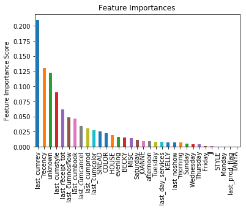

```python
gbm0 = GradientBoostingClassifier(random_state=483)
modelfit(gbm0, X, y, cv_folds = 5)
```

Let's set some of the parameters to a fixed value and perform grid search with cross-validation on the whole dataset to identify a proper number of estimators (number of trees built on top of each other) based on the maximization of `accuracy` score rather than `roc_auc`.

```python
from sklearn.grid_search import GridSearchCV

param_test1 = {'n_estimators':np.arange(50,301,10)}
gsearch1 = GridSearchCV(estimator = GradientBoostingClassifier(learning_rate=0.1,
                                                               min_samples_split=50,
                                                               min_samples_leaf=50,
                                                               max_depth=4,
                                                               max_features='sqrt',
                                                               random_state=483),
param_grid = param_test1, scoring = 'accuracy',n_jobs=4, iid=False, cv=5)
gsearch1.fit(X,y)
```

```
GridSearchCV(cv=5, error_score='raise',
       estimator=GradientBoostingClassifier(criterion='friedman_mse', init=None,
              learning_rate=0.1, loss='deviance', max_depth=4,
              max_features='sqrt', max_leaf_nodes=None,
              min_impurity_decrease=0.0, min_impurity_split=None,
              min_samples_leaf=50, min_samples_split=50,
              min_weight_fraction_leaf=0.0, n_estimators=100,
              presort='auto', random_state=483, subsample=1.0, verbose=0,
              warm_start=False),
       fit_params={}, iid=False, n_jobs=4,
       param_grid={'n_estimators': array([ 50,  60,  70,  80,  90, 100, 110, 120, 130, 140, 150, 160, 170,
       180, 190, 200, 210, 220, 230, 240, 250, 260, 270, 280, 290, 300])},
       pre_dispatch='2*n_jobs', refit=True, scoring='accuracy', verbose=0)
```

```python
gsearch1.grid_scores_, gsearch1.best_params_, gsearch1.best_score_
```

```
([mean: 0.90369, std: 0.00797, params: {'n_estimators': 50},
  mean: 0.90472, std: 0.00629, params: {'n_estimators': 60},
  mean: 0.90267, std: 0.00533, params: {'n_estimators': 70},
  mean: 0.90420, std: 0.00527, params: {'n_estimators': 80},
  mean: 0.90574, std: 0.00466, params: {'n_estimators': 90},
  mean: 0.90471, std: 0.00408, params: {'n_estimators': 100},
  mean: 0.90625, std: 0.00473, params: {'n_estimators': 110},
  mean: 0.90676, std: 0.00784, params: {'n_estimators': 120},
  mean: 0.90471, std: 0.00635, params: {'n_estimators': 130},
  mean: 0.90523, std: 0.00625, params: {'n_estimators': 140},
  mean: 0.90625, std: 0.00659, params: {'n_estimators': 150},
  mean: 0.90471, std: 0.00658, params: {'n_estimators': 160},
  mean: 0.90574, std: 0.00814, params: {'n_estimators': 170},
  mean: 0.90677, std: 0.00922, params: {'n_estimators': 180},
  mean: 0.90881, std: 0.00865, params: {'n_estimators': 190},
  mean: 0.90779, std: 0.00823, params: {'n_estimators': 200},
  mean: 0.90677, std: 0.00922, params: {'n_estimators': 210},
  mean: 0.90625, std: 0.00865, params: {'n_estimators': 220},
  mean: 0.90676, std: 0.00784, params: {'n_estimators': 230},
  mean: 0.90881, std: 0.00865, params: {'n_estimators': 240},
  mean: 0.90779, std: 0.00971, params: {'n_estimators': 250},
  mean: 0.90830, std: 0.01038, params: {'n_estimators': 260},
  mean: 0.90831, std: 0.01180, params: {'n_estimators': 270},
  mean: 0.90779, std: 0.00994, params: {'n_estimators': 280},
  mean: 0.90728, std: 0.01108, params: {'n_estimators': 290},
  mean: 0.90471, std: 0.00831, params: {'n_estimators': 300}],
 {'n_estimators': 190},
 0.9088134769172778)
```

### Final model

The optimal `n_estimators` is 190. Let's use this number to build the final model.

```
Model Report
Test\Train split    : 0.3333
Accuracy (Train)    : 0.9493
Accuracy (Test)     : 0.9171
AUC Score (Train)   : 0.951411
AUC Score (Test)    : 0.826624
```

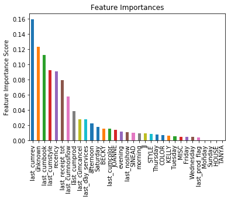

```python
gbm1 = GradientBoostingClassifier(learning_rate=0.1,
                                  min_samples_split=50,
                                  min_samples_leaf=50,
                                  max_depth=4,
                                  max_features='sqrt',
                                  n_estimators = 190,
                                  random_state=483)

modelfit(gbm1, X, y, performCV = False)
```

As compared to the previous model, the `accuracy` score on test gained 0.017 and `roc-auc` dropped a little to 0.8266 as compared to 0.84 previously which is the consequence of the accuracy maximization during parameter optimization process.

**Feature importance**

In the final model top-5 features are slightly different. The most informative feature here are:

- `last_cumrev` -- *the client's cumulative service revenue as of their last booking before the current booking or today whichever is greater*,
- `unknown` -- *the daytime of the booking is unknown*,
- `last_cumbook` -- *the client's cumulative number of bookings as of their last booking before the current booking or today whichever is greater*,
- `last_cumstyle` -- *the client's cumulative number of STYLE bookings as of their last booking before the current booking or today whichever is greater*
- `recency` -- *The number of days since the client's last booking before the current booking or today whichever is greater.*

Unfortunately, within Gradient Boosting model we cannot easily estimate the direction of the link between the dependent and independent variables. I suggest to use `LIME` package to better understand the model.

## LIME interpretation

```python
import lime
from lime.lime_tabular import LimeTabularExplainer

X_train, X_test, y_train, y_test = train_test_split(X, y, test_size = 1/3, random_state = 483) # 2/3 - train, 1/3 - test

explainer = LimeTabularExplainer(X_train, mode='classification',
                                 feature_names=list(noshow.iloc[:, noshow.columns != 'noshow']))
```

Let's select one example that was correctly predicted to be a no-show. The LIME interpreter will generate a lot of examples like it and run a regression on them to evaluate the features' effect. As a result, we get a graph explaining the input of each feature into the prediction of `1`.

```python
pred = gbm1.predict(X_test)
for i in range(0,21,1):
    print(i, y_test[i], pred[i], y_test[i] == pred[i])
```

```
0 0 0 True
1 0 0 True
2 0 0 True
3 0 0 True
4 0 0 True
5 0 0 True
6 0 0 True
7 0 0 True
8 0 0 True
9 0 0 True
10 0 0 True
11 0 0 True
12 0 0 True
13 0 0 True
14 0 0 True
15 0 0 True
16 1 0 False
17 0 0 True
18 0 0 True
19 1 1 True
20 0 0 True
```

```python
exp = explainer.explain_instance(X_test[19,:], gbm1.predict_proba)
exp.show_in_notebook()
```

[output not shown]

Let's take one correctly predicted zero (the client showed up).

```python
exp = explainer.explain_instance(X_test[20,:], gbm1.predict_proba)
exp.show_in_notebook()
```

[output not shown]

## Conclusion

The Gradient Boosting model shows pretty good quality of the prediction. From the hair salon owner's point of view the model can be used as a black box to predict and manage daily costs or he/she can gain some understanding of the mechanisms causing no shows by eploring different cases with `LIME`.